# Assignment 2, Part B

Ajul Thomas (u3253992@uni.canberra.edu.au)

2023-10-02

# Part B - Data Wrangling (33 marks)

**Perform the following tasks**

## 1. Load the `act_weather_data_partA.csv` into a data frame or a tibble, named, `act_weather_data`. (1 mark)

```r
# solution and documentation of the code goes below this line ...

library(tidyverse)
# reads data as a tibble
act_weather_data <- read_csv('output/act_weather_data_partA.csv')
```

```
## ──────────────────────────────────────────────────────── Delimiter: "," chr
## (6): Month, Direction_of_maximum_wind_gust, 9am_wind_direction, 9am_wi... dbl
## (14): ...1, Year, Minimum_temperature, Maximum_temperature, Rainfall_(m... date
## (1): Date time (1): Time_of_maximum_wind_gust
```

```r
str(act_weather_data)
```

```
## spc_tbl_ [1,582 × 22] (S3: spec_tbl_df/tbl_df/tbl/data.frame)
##  $ ...1                             : num [1:1582] 1 2 3 4 5 6 7 8 9 10 ...
##  $ Date                             : Date[1:1582], format: "2018-08-01" "2018-08-02" ...
##  $ Year                             : num [1:1582] 2018 2018 2018 2018 2018 ...
##  $ Month                            : chr [1:1582] "08" "08" "08" "08" ...
##  $ Minimum_temperature              : num [1:1582] 7.6 -3.8 -3.6 3.7 -1 1.2 2.4 2.6 1.6 -2.5 ...
##  $ Maximum_temperature              : num [1:1582] 15.4 14.3 19.5 12.8 15 13.7 9.7 12.1 13.7 15.6 ...
##  $ Rainfall_(mm)                    : num [1:1582] 0 0 0 13.8 0 0 6.6 0 0 0.2 ...
##  $ Direction_of_maximum_wind_gust   : chr [1:1582] "NW" "NNW" "NW" "NNW" ...
##  $ Speed_of_maximum_wind_gust_(km/h): num [1:1582] 54 26 72 54 43 61 61 70 30 43 ...
##  $ Time_of_maximum_wind_gust        : 'hms' num [1:1582] 01:38:00 12:23:00 20:56:00 04:50:00 ...
##   ..- attr(*, "units")= chr "secs"
##  $ 9am_Temperature                  : num [1:1582] 10.9 3.3 3.7 7.8 5 9.2 4.9 6.5 6.3 0.5 ...
##  $ 9am_relative_humidity_(%)        : num [1:1582] 54 87 84 77 85 72 90 65 94 99 ...
##  $ 9am_cloud_amount_(oktas)         : num [1:1582] 6.58 1 6.58 8 6.58 ...
##  $ 9am_wind_direction               : chr [1:1582] "WNW" "NNW" "NNW" "NNW" ...
##  $ 9am_wind_speed_(km/h)            : chr [1:1582] "22" "Calm" "Calm" "24" ...
##  $ 9am_MSL_pressure_(hPa)           : num [1:1582] 1019 1027 1018 1017 1018 ...
##  $ 3pm_Temperature                  : num [1:1582] 14.7 13.7 17.9 11.6 14.6 10.9 8.8 9.9 12.9 14.9 ...
##  $ 3pm_relative_humidity_(%)        : num [1:1582] 32 43 35 52 48 44 54 60 50 42 ...
##  $ 3pm_cloud_amount_(oktas)         : num [1:1582] 5.66 5.66 4 5 5.66 ...
##  $ 3pm_wind_direction               : chr [1:1582] "NW" "NE" "NNW" "WNW" ...
##  $ 3pm_wind_speed_(km/h)            : chr [1:1582] "19" "9" "39" "22" ...
##  $ 3pm_MSL_pressure_(hPa)           : num [1:1582] 1019 1022 1010 1016 1012 ...
##  - attr(*, "spec")=
##   .. cols(
##   ..   ...1 = col_double(),
##   ..   Date = col_date(format = ""),
##   ..   Year = col_double(),
##   ..   Month = col_character(),
##   ..   Minimum_temperature = col_double(),
##   ..   Maximum_temperature = col_double(),
##   ..   `Rainfall_(mm)` = col_double(),
##   ..   Direction_of_maximum_wind_gust = col_character(),
##   ..   `Speed_of_maximum_wind_gust_(km/h)` = col_double(),
##   ..   Time_of_maximum_wind_gust = col_time(format = ""),
##   ..   `9am_Temperature` = col_double(),
##   ..   `9am_relative_humidity_(%)` = col_double(),
##   ..   `9am_cloud_amount_(oktas)` = col_double(),
##   ..   `9am_wind_direction` = col_character(),
##   ..   `9am_wind_speed_(km/h)` = col_character(),
##   ..   `9am_MSL_pressure_(hPa)` = col_double(),
##   ..   `3pm_Temperature` = col_double(),
##   ..   `3pm_relative_humidity_(%)` = col_double(),
##   ..   `3pm_cloud_amount_(oktas)` = col_double(),
##   ..   `3pm_wind_direction` = col_character(),
##   ..   `3pm_wind_speed_(km/h)` = col_character(),
##   ..   `3pm_MSL_pressure_(hPa)` = col_double()
##   .. )
##  - attr(*, "problems")=<externalptr>
```

## 2. Print the summary including the (minimum, median, mean, maximum) of each of the following variables: (5 marks)

- `Minimum_temperature`,
- `Maximum_temperature`,
- `9am_Temperature`,
- `Speed_of_maximum_wind_gust_(km/h)`, and
- `3pm_Temperature`

```r
# solution and documentation of the code goes below this line ...

cols_to_display <- c('Minimum_temperature', 'Maximum_temperature', '9am_Temperature',  'Speed_of_maximum_wind_gust_(km/h)', '3pm_Temperature')

act_weather_data %>%
  # select the columns to be displayed
  select(all_of(cols_to_display)) %>%
  # get the summary stats of the selected coloumns
  summary()
```

```
##  Minimum_temperature Maximum_temperature 9am_Temperature
##  Min.   :-6.500      Min.   : 6.30       Min.   :-0.80
##  1st Qu.: 2.500      1st Qu.:15.22       1st Qu.: 8.80
##  Median : 7.400      Median :20.70       Median :13.50
##  Mean   : 7.353      Mean   :21.15       Mean   :13.13
##  3rd Qu.:12.200      3rd Qu.:26.10       3rd Qu.:17.30
##  Max.   :26.700      Max.   :44.00       Max.   :34.50
##  Speed_of_maximum_wind_gust_(km/h) 3pm_Temperature
##  Min.   : 13.00                    Min.   : 4.70
##  1st Qu.: 33.00                    1st Qu.:13.90
##  Median : 41.00                    Median :19.10
##  Mean   : 41.72                    Mean   :19.62
##  3rd Qu.: 50.00                    3rd Qu.:24.50
##  Max.   :117.00                    Max.   :42.30
```

## 3. Based on the minimum and maximum temperature columns, compute the average temperature per month. Please note that we have 52 months provided in the data, so there will be 52 generated values. (4 marks)

```r
# solution and documentation of the code goes below this line ...

act_weather_data %>%
  # selects required columns
  select(Year, Month, Maximum_temperature, Minimum_temperature) %>%
  # creates a new column to store the average daily temperature
  mutate(average_temperature = (Maximum_temperature + Minimum_temperature)/2) %>%
  # groups the data by Year and month
  group_by(Year, Month) %>%
  # summarises the data for each month of each year
  summarise(average_monthly_temperature=mean(average_temperature))
```

[output not shown]

## 4. What is the average speed of maximum wind gust for each group of the direction of maximum wind gust? (2 marks)

```r
# solution and documentation of the code goes below this line ...

act_weather_data %>%
  # groups the data by direction of maximum wind gust
  group_by(Direction_of_maximum_wind_gust) %>%
  # for each wind direction calculates the mean of speed of maximum wind gust
  summarise(average_speed_max_wind_gust = mean(`Speed_of_maximum_wind_gust_(km/h)`))
```

```
## # A tibble: 16 × 2
##    Direction_of_maximum_wind_gust average_speed_max_wind_gust
##    <chr>                                                <dbl>
##  1 E                                                     39.2
##  2 ENE                                                   37.1
##  3 ESE                                                   39.1
##  4 N                                                     35.7
##  5 NE                                                    33.7
##  6 NNE                                                   30.4
##  7 NNW                                                   42.4
##  8 NW                                                    46.5
##  9 S                                                     44.5
## 10 SE                                                    36
## 11 SSE                                                   40.2
## 12 SSW                                                   40.5
## 13 SW                                                    44.5
## 14 W                                                     45.4
## 15 WNW                                                   48.5
## 16 WSW                                                   40.6
```

## 5. Which month has the highest average rain fall? And in which year? (2 marks)

- ( *hint:* in this question you may use group_by, summarise and which.max functions)

```r
# solution and documentation of the code goes below this line ...

highest_rainfall <- act_weather_data %>%
  # selects year, month and rainfall columns
  select(Year, Month, `Rainfall_(mm)`) %>%
  # creates a new column for easier grouping
  mutate(YearMonth=paste(Year,Month, sep = "-")) %>%
  # groups by the new Year Month Column
  group_by(YearMonth) %>%
  # calculates the average rainfall for each month of each year
  summarise(average_rainfall = mean(`Rainfall_(mm)`)) %>%
  # selects the row for which the rainfall is maximum
  summarise(YearMonth=YearMonth[which.max(average_rainfall)], max_rainfall=max(average_rainfall))

highest_rainfall
```

```
## # A tibble: 1 × 2
##   YearMonth max_rainfall
##   <chr>            <dbl>
## 1 2022-10           5.36
```

## 6. Which month was the driest in average, ( *i.e.*, least amount of rainfall in average)? And in which year? (3 marks)

```r
# solution and documentation of the code goes below this line ...

act_weather_data %>%
  # selects year, month and rainfall columns
  select(Year, Month, `Rainfall_(mm)`) %>%
  # creates a new column for easier grouping
  mutate(YearMonth=paste(Year,Month, sep = "-")) %>%
  # groups by the new Year Month Column
  group_by(YearMonth) %>%
  # calculates the average rainfall for each month of each year
  summarise(average_rainfall = mean(`Rainfall_(mm)`)) %>%
  # selects the row for which the rainfall is minimum
  summarise(YearMonth=YearMonth[which.min(average_rainfall)], max_rainfall=min(average_rainfall))
```

```
## # A tibble: 1 × 2
##   YearMonth max_rainfall
##   <chr>            <dbl>
## 1 2019-12         0.0387
```

## 7. For the humidity, which month was receiving highest humidity level, in average, in the 2019 year? (3 marks)

```r
# solution and documentation of the code goes below this line ...

act_weather_data %>%
  # filters data for the year 2019
  filter(Year == 2019) %>%
  # creates a ne column to store the average daily humidity
  mutate(average_daily_humidity=(`9am_relative_humidity_(%)`+`3pm_relative_humidity_(%)`)/2) %>%
  # groups the data by month
  group_by(Month) %>%
  # summarises the data to obtain average humidity for each month
  summarise(average_humidity=mean(average_daily_humidity)) %>%
  # selects the row for which average_humidity is maximum
  summarise(month=Month[which.max(average_humidity)], average_humidity=max(average_humidity))
```

```
## # A tibble: 1 × 2
##   month average_humidity
##   <chr>            <dbl>
## 1 06                72.5
```

## 8. For the period between August 2020 and July 2021 inclusive, Can you generate a summary table showing the minimum, maximum and average temperature (please use the `3 pm temperature` column), wind speed and humidity for each month and each quarter in the year? (5 marks)

```r
# solution and documentation of the code goes below this line ...

quarter_summary_df <- act_weather_data %>%
  # converts the non-numeric values in wind speed column to numeric, and replaces the value 'calm' with 0
  mutate(`9am_wind_speed_(km/h)` = ifelse(`9am_wind_speed_(km/h)` == "Calm", 0, as.numeric(`9am_wind_speed_(km/h)`))) %>%
  mutate(`3pm_wind_speed_(km/h)` = ifelse(`3pm_wind_speed_(km/h)` == "Calm", 0, as.numeric(`3pm_wind_speed_(km/h)`))) %>%
  # filters out data for the required range
  filter(Date >= "2020-08-01" & Date <= "2021-07-31") %>%
  # creates new columns to store the average daily readings and to store the quarter details
  mutate(
    wind_speed = as.numeric((`9am_wind_speed_(km/h)` +`3pm_wind_speed_(km/h)`)/2),
    temperature = as.numeric(`3pm_Temperature`),
    humidity = as.numeric((`9am_relative_humidity_(%)`+`3pm_relative_humidity_(%)`)/2),
    Quarter = quarter(Date)
    ) %>%
  # groups data by the quarter column just created
  group_by(Quarter) %>%
  # calculates the min, max and mean values of temperature, win speed and humidity for each quarter
  summarise(
    min_temp = min(temperature, na.rm = T),
    max_temp = max(temperature, na.rm = T),
    mean_temp = mean(temperature, na.rm = T),
    min_windSpeed = min(wind_speed, na.rm = T),
    max_windSpeed = max(wind_speed, na.rm = T),
    mean_windSpeed = mean(wind_speed, na.rm = T),
    min_humidity = min(humidity, na.rm = T),
    max_humidity = max(humidity, na.rm = T),
    mean_humidity = mean(humidity, na.rm = T)
  )
monthly_summary_df <- act_weather_data %>%
  # converts the non-numeric values in wind speed column to numeric, and replaces the value 'calm' with 0
  mutate(`9am_wind_speed_(km/h)` = ifelse(`9am_wind_speed_(km/h)` == "Calm", 0, as.numeric(`9am_wind_speed_(km/h)`))) %>%
  mutate(`3pm_wind_speed_(km/h)` = ifelse(`3pm_wind_speed_(km/h)` == "Calm", 0, as.numeric(`3pm_wind_speed_(km/h)`))) %>%
  # filters out data for the required range
  filter(Date >= "2020-08-01" & Date <= "2021-07-31") %>%
  # creates new columns to store the average daily readings and to store the quarter details
  mutate(
    wind_speed = as.numeric((`9am_wind_speed_(km/h)` +`3pm_wind_speed_(km/h)`)/2),
    temperature = as.numeric(`3pm_Temperature`),
    humidity = as.numeric((`9am_relative_humidity_(%)`+`3pm_relative_humidity_(%)`)/2),
    ) %>%
  # groups data by the quarter column just created
  group_by(Month) %>%
  # calculates the min, max and mean values of temperature, win speed and humidity for each month
  summarise(
    min_temp = min(temperature, na.rm = T),
    max_temp = max(temperature, na.rm = T),
    mean_temp = mean(temperature, na.rm = T),
    min_windSpeed = min(wind_speed, na.rm = T),
    max_windSpeed = max(wind_speed, na.rm = T),
    mean_windSpeed = mean(wind_speed, na.rm = T),
    min_humidity = min(humidity, na.rm = T),
    max_humidity = max(humidity, na.rm = T),
    mean_humidity = mean(humidity, na.rm = T)
  )
quarter_summary_df
```

```
## # A tibble: 4 × 10
##   Quarter min_temp max_temp mean_temp min_windSpeed max_windSpeed mean_windSpeed
##     <int>    <dbl>    <dbl>     <dbl>         <dbl>         <dbl>          <dbl>
## 1       1     13.6     36.2      23.9           3.5          32.5           14.5
## 2       2      8       27.6      15.6           2            36.5           13.9
## 3       3      5.7     23.1      12.7           0            33             17.6
## 4       4      9.1     34.2      22.1           4            41.5           16.6
## # ℹ 3 more variables: min_humidity <dbl>, max_humidity <dbl>,
## #   mean_humidity <dbl>
```

```r
monthly_summary_df
```

```
## # A tibble: 12 × 10
##    Month min_temp max_temp mean_temp min_windSpeed max_windSpeed mean_windSpeed
##    <chr>    <dbl>    <dbl>     <dbl>         <dbl>         <dbl>          <dbl>
##  1 01        15       36.2      26.0           4.5          29.5           15.5
##  2 02        18.5     29.4      24.2           4.5          32.5           14.2
##  3 03        13.6     28.4      21.5           3.5          29             13.9
##  4 04        13.1     27.6      19.8           2            32             13.2
##  5 05        10.7     21.4      15.2           5.5          34.5           14.0
##  6 06         8       16.8      11.7           3.5          36.5           14.6
##  7 07         5.8     14.6      10.3           0            29.5           17.3
##  8 08         5.9     17.9      11.4           3            33             18.7
##  9 09         5.7     23.1      16.3           8            31             16.8
## 10 10        11.3     26        19.0           4            27.5           15.8
## 11 11         9.1     34.2      23.6           9.5          41.5           16.8
## 12 12        18.4     32.1      23.8           8            34             17.3
## # ℹ 3 more variables: min_humidity <dbl>, max_humidity <dbl>,
## #   mean_humidity <dbl>
```

## 9. Build graph(s) that show the distribution of the variables in the question #8. (5 marks)

- ( *hint:* There will be six graphs where each of them include distributions of minimum, maximum and average of variables temperature, wind speed or humidity per month and quarter.

```r
month_year_data <-  act_weather_data %>%
  # converts the non-numeric values in wind speed column to numeric, and replaces the value 'calm' with 0
  mutate(`9am_wind_speed_(km/h)` = ifelse(`9am_wind_speed_(km/h)` == "Calm", 0, as.numeric(`9am_wind_speed_(km/h)`))) %>%
  mutate(`3pm_wind_speed_(km/h)` = ifelse(`3pm_wind_speed_(km/h)` == "Calm", 0, as.numeric(`3pm_wind_speed_(km/h)`))) %>%
  # creates a new column for easier grouping and visualization
  mutate(YearMonth=paste(Year,Month,sep = "-")) %>%
  # filters out data for the required range
  filter(Date >= "2020-08-01" & Date <= "2021-07-31") %>%
  # creates new columns to store the average daily readings and to store the quarter details
  mutate(
    wind_speed = as.numeric((`9am_wind_speed_(km/h)` +`3pm_wind_speed_(km/h)`)/2),
    temperature = as.numeric(`3pm_Temperature`),
    humidity = as.numeric((`9am_relative_humidity_(%)`+`3pm_relative_humidity_(%)`)/2),
    Quarter = quarter(Date)
    ) %>%
  # groups data by Year and Month
  group_by(YearMonth) %>%
  # calculates the min, max and mean values of temperature, win speed and humidity for each quarter of each year
  summarise(
    min_temp = min(temperature, na.rm = T),
    max_temp = max(temperature, na.rm = T),
    mean_temp = mean(temperature, na.rm = T),
    min_windSpeed = min(wind_speed, na.rm = T),
    max_windSpeed = max(wind_speed, na.rm = T),
    mean_windSpeed = mean(wind_speed, na.rm = T),
    min_humidity = min(humidity, na.rm = T),
    max_humidity = max(humidity, na.rm = T),
    mean_humidity = mean(humidity, na.rm = T)
  )
month_year_data
```

```
## # A tibble: 12 × 10
##    YearMonth min_temp max_temp mean_temp min_windSpeed max_windSpeed
##    <chr>        <dbl>    <dbl>     <dbl>         <dbl>         <dbl>
##  1 2020-08        5.9     17.9      11.4           3            33
##  2 2020-09        5.7     23.1      16.3           8            31
##  3 2020-10       11.3     26        19.0           4            27.5
##  4 2020-11        9.1     34.2      23.6           9.5          41.5
##  5 2020-12       18.4     32.1      23.8           8            34
##  6 2021-01       15       36.2      26.0           4.5          29.5
##  7 2021-02       18.5     29.4      24.2           4.5          32.5
##  8 2021-03       13.6     28.4      21.5           3.5          29
##  9 2021-04       13.1     27.6      19.8           2            32
## 10 2021-05       10.7     21.4      15.2           5.5          34.5
## 11 2021-06        8       16.8      11.7           3.5          36.5
## 12 2021-07        5.8     14.6      10.3           0            29.5
## # ℹ 4 more variables: mean_windSpeed <dbl>, min_humidity <dbl>,
## #   max_humidity <dbl>, mean_humidity <dbl>
```

```r
df_to_plot <-  month_year_data %>%
  # changes the Year Month coloumn to an ordinal factor
  mutate(YearMonth=factor(YearMonth, unique(YearMonth), ordered = T)) %>%
  # reduces the width of the column, for easier plotting
  gather(key = "attribute", value="avg_measure", min_temp:mean_humidity) %>%
  # seperates the column to obtain the quatity being measured and metric used
  separate(col = attribute, into = c("type", "variable"), sep = "_")

str(df_to_plot)
```

```
## tibble [108 × 4] (S3: tbl_df/tbl/data.frame)
##  $ YearMonth  : Ord.factor w/ 12 levels "2020-08"<"2020-09"<..: 1 2 3 4 5 6 7 8 9 10 ...
##  $ type       : chr [1:108] "min" "min" "min" "min" ...
##  $ variable   : chr [1:108] "temp" "temp" "temp" "temp" ...
##  $ avg_measure: num [1:108] 5.9 5.7 11.3 9.1 18.4 15 18.5 13.6 13.1 10.7 ...
```

```r
df_to_plot
```

```
## # A tibble: 108 × 4
##    YearMonth type  variable avg_measure
##    <ord>     <chr> <chr>          <dbl>
##  1 2020-08   min   temp             5.9
##  2 2020-09   min   temp             5.7
##  3 2020-10   min   temp            11.3
##  4 2020-11   min   temp             9.1
##  5 2020-12   min   temp            18.4
##  6 2021-01   min   temp            15
##  7 2021-02   min   temp            18.5
##  8 2021-03   min   temp            13.6
##  9 2021-04   min   temp            13.1
## 10 2021-05   min   temp            10.7
## # ℹ 98 more rows
```

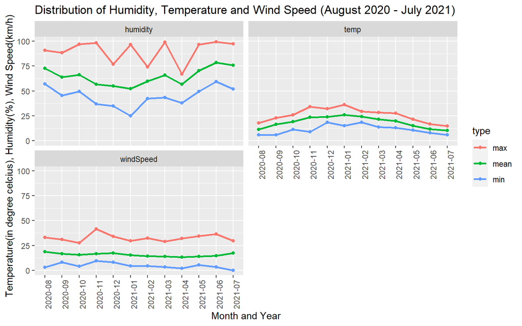

```r
# Create a ggplot object using the data frame df_to_plot
ggplot(df_to_plot, aes(x=YearMonth, y=avg_measure, colour=type))+
  # Add points to the plot to represent data points.
  geom_point(aes(y=avg_measure, colour=type))+
  # Add lines connecting the points for each type (grouped by type).
  geom_path(aes(y=avg_measure, colour=type, group=type), size=1)+
  # Add labels and titles to the plot.
  labs(
    title = "Distribution of Humidity, Temperature and Wind Speed (August 2020 - July 2021)",
    x = "Month and Year",
    y = "Temperature(in degree celcius), Humidity(%), Wind Speed(km/h)"
    ) +
   # Create facets (subplots) based on the 'variable' column from the data frame.
  facet_wrap(~variable, ncol = 2) +
  # Adjust the appearance of the x-axis labels to be more readable.
  theme(axis.text.x = element_text(angle = 90, hjust = 1))
```